# 7.0 Evaluate Fish Data from PWD

J Hagy

2025-05-12

The Philadelphia Water Department contributed data during the public comment period for EPA’s consideration. In this program these data are evaluated to determine their potential relevance and utility for derivation of protective dissolved oxygen criteria.

## Load Data Sets

Comma separated files extracted from XLSX file provided by PWD.

```r
Brundage.2009 <- read.csv(here("raw","Brundage_2009.csv")) %>%
  mutate(Date=as.Date(Date,format="%m/%d/%Y"),
         source="Brundage 2009")
calvo <- read.csv(here("raw","2010_Calvo.csv")) %>%
  mutate(Date=as.Date(Date,format="%m/%d/%Y"),
         source="Calvo 2010")
ERC.2016 <- read.csv(here("raw","2016_ERC_Report.csv")) %>%
  mutate(Date=as.Date(Date,format="%m/%d/%Y"),
         source="2016 ERC Report")
ERC.2017 <- read.csv(here("raw","2017_ERC_Report.csv")) %>%
  mutate(Date=as.Date(Date,format="%m/%d/%Y"),
         source="2017 ERC Report")
ERC.2018 <- read.csv(here("raw","2018_ERC_Report.csv")) %>%
  mutate(Date=as.Date(Date,format="%m/%d/%Y"),
         source="2018 ERC Report")
ERC.2019 <- read.csv(here("raw","2019_ERC_Report.csv")) %>%
  mutate(Date=as.Date(Date,format="%m/%d/%Y"),
         source="2019 ERC Report")

Park.2020 <- rbind(
  read.csv(here("raw","2020 Park.csv"),skip=2) %>%
  mutate(Date=as.Date(Original.Tag.Date,format="%m/%d/%Y"),
         source="Park 2020",
         Location="Not Specified") %>%
  rename(Fork.Length_mm = Fork.Length..mm.,
         Total.Length_mm = Total.Length..mm.,
         Weight_g = Weight..kg.) %>%
  select(Date,Location,Fork.Length_mm,Total.Length_mm,Weight_g,source),

  read.csv(here("raw","2020 Park.csv"),skip=2) %>%
  mutate(Date=as.Date(Recapture.Date,format="%m/%d/%Y"),
         source="Park 2020",
         Location="Not Specified") %>%
  rename(Fork.Length_mm = Fork.Length..mm..1,
         Total.Length_mm = Total.Length..mm..1,
         Weight_g = Weight..kg..1) %>%
  select(Date,Location,Fork.Length_mm,Total.Length_mm,Weight_g,source)
)
```

# Combine the Data

```r
fish.data <- rbind(
  select(Brundage.2009,all_of(c("Date","Location","Total.Length_mm","Weight_g","source"))),
  select(calvo,all_of(c("Date","Location","Total.Length_mm","Weight_g","source"))),
  select(ERC.2016,all_of(c("Date","Location","Total.Length_mm","Weight_g","source"))),
  select(ERC.2017,all_of(c("Date","Location","Total.Length_mm","Weight_g","source"))),
  select(ERC.2018,all_of(c("Date","Location","Total.Length_mm","Weight_g","source"))),
  select(ERC.2019,all_of(c("Date","Location","Total.Length_mm","Weight_g","source"))),
  select(Park.2020,all_of(c("Date","Location","Total.Length_mm","Weight_g","source")))
  ) %>%
  mutate(source=factor(source),
         doy.as.date=as.Date(paste0("1969-",format(Date,format="%m-%d"))))

#size.on.date <- size.on.date %>%
#  mutate(doy.as.date=as.Date(yday(Date),origin="1969-12-31"))

fish.data <- fish.data %>%
  mutate(doy = yday(Date),
         year=year(Date))

df <- fish.data %>%
  filter(Total.Length_mm<500) %>%
  mutate(year_class = ifelse(month(Date)<7,year(Date)-1,year(Date))) %>%
  filter(Location =="Marcus Hook Anchorage") %>%
  group_by(year_class) %>%
  summarize(mean.doy = mean(doy,na.rm=TRUE))

table(fish.data$Location,fish.data$year)
```

```
##
##                            2005 2006 2009 2014 2015 2016 2017 2018 2019
##   Bellevue Range              0    0    0    0    0    0    2    0   23
##   Chester-Eddystone Ranges    0    0    0    0    0    4    0    0    0
##   Chester Range               0    0    0    0    0    6    0    0    0
##   Chester/Eddystone ranges    0    0    0    0    0    0    0    3    0
##   Eddystone Range             0    0    0    0   10   36    0    0   21
##   Eddystone/Tinicum           0    0    0    0    0    0    0    5    0
##   Marcus Hook anchorage       3    1   51    0    0    0    0    0    0
##   Marcus Hook Anchorage       0    0    0    0  406  248 1845  674 1090
##   Marcus Hook Range           0    0    0    0    0    0    9   46  134
##   Not Specified               0    0    0    6    8    6   87   25   12
##   Tinicum                     0    0    0    0    0    4    0    0    0
##   Tinicum-Eddystone Ranges    0    0    0    0    0   19    0    0    0
##   Tinicum Range               0    0    0    0   66  256    7    0   91
##   Upper Cherry Isl. Flats     0    0    2    0    0    0    0    0    0
##   Wilmington                  1    1    0    0    0    0    0    0    0
```

## Tabulate data by report, year and month.

```r
fish.data$year=year(fish.data$Date)
fish.data$month=month(fish.data$Date)

table(fish.data$year,fish.data$source)
```

```
##
##        2016 ERC Report 2017 ERC Report 2018 ERC Report 2019 ERC Report
##   2005               0               0               0               0
##   2006               0               0               0               0
##   2009               0               0               0               0
##   2014               0               0               0               0
##   2015             482               0               0               0
##   2016             293             280               0               0
##   2017               0              85            1778               0
##   2018               0               0             728               0
##   2019               0               0               0            1359
##
##        Brundage 2009 Calvo 2010 Park 2020
##   2005             4          0         0
##   2006             2          0         0
##   2009             0         53         0
##   2014             0          0         6
##   2015             0          0         8
##   2016             0          0         6
##   2017             0          0        87
##   2018             0          0        25
##   2019             0          0        12
```

```r
table(fish.data$month,fish.data$source)
```

```
##
##      2016 ERC Report 2017 ERC Report 2018 ERC Report 2019 ERC Report
##   1               47              39             310              90
##   2               39              31             418             974
##   3              207              15               0             293
##   7                0               0               0               0
##   8                0               0               0               2
##   9                0               0               0               0
##   10               0               0               0               0
##   11               0             184            1002               0
##   12             482              96             776               0
##
##      Brundage 2009 Calvo 2010 Park 2020
##   1              0          0         6
##   2              0          0        12
##   3              0          0         4
##   7              1          1         0
##   8              2          3         0
##   9              3         27         0
##   10             0         15        13
##   11             0          7        65
##   12             0          0        44
```

```r
# How many are YOY (defined as <500 g)?
fish.data <- fish.data %>%
  mutate(size_class=cut(Weight_g,breaks=c(0,500,10000),labels=c("<500 g",">500 g")))

100*table(fish.data$size_class)/nrow(fish.data)
```

```
##
##   <500 g   >500 g
## 82.06605 17.87634
```

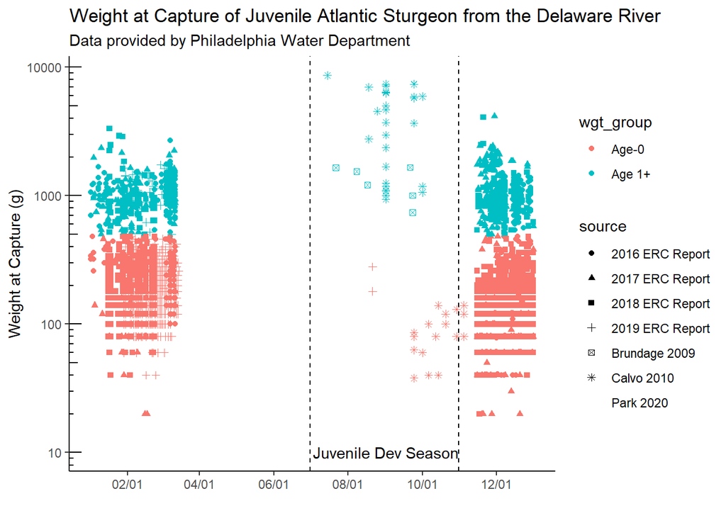

```r
fish.data <- fish.data %>% mutate(wgt_group = ifelse(Weight_g>=500,"Age 1+","Age-0")) %>%
  filter(!is.na(Weight_g))

ggplot(fish.data,aes(x=doy.as.date,y=Weight_g,shape=source,color=wgt_group))+
  geom_point()+
  scale_y_log10()+
  annotation_logticks(sides="l")+
  theme_classic()+
  scale_x_date(date_labels="%m/%d",date_breaks="2 months")+
  geom_vline(xintercept=as.Date(c("1969-07-01","1969-10-31")),linetype=2)+
  annotate("text",x=as.Date("1969-09-01"),y=10,label="Juvenile Dev Season")+
  labs(x="",y="Weight at Capture (g)")+
  ggtitle("Weight at Capture of Juvenile Atlantic Sturgeon from the Delaware River",
          subtitle = "Data provided by Philadelphia Water Department")
```

Most of the observations were collected in November - March. A few observations were collected by Brundage 2009 during summer, but these are larger age 1+ fish. Calvo (2010) includes a significant number of individuals captured during September, which augments the data from Park 2020 that the EPA used in the proposed rule. The captures reported in the 2018 and 2019 ERC Reports are overwhelmingly from November through March. These account for many of the observations of fish weight because of the strong year class in 2018.

Fish smaller than 500 g are most likely from the Ago-0 year class and account for 82% of the sampled individuals.

## Water Temperature

To compare the distribution of fish weights from these data with expected growth, we need a time series of water temperature. Here I calculate the long term median and extract the data for 2018. The water temperature from 2018 is most appropriate for comparison with the fish size data because most of the individuals are from the 2018 year class. Calculating the median illustrates that water temperatures in 2018 were somewhat below the median.

```r
# df contains the water temperature data from Chester and Penn Landing for all
# the years since 2002.
df.2018 <- df %>% filter(year(date) %in% c(2018))

# Calculate the median by day of year
df.med <- df %>% group_by(site,doy) %>%
  summarize(wt.med = median(wt.mean)) %>%
  mutate(doy.as.date=as.Date(doy,origin=as.Date("1969-12-31"))) %>%
  ungroup()
```

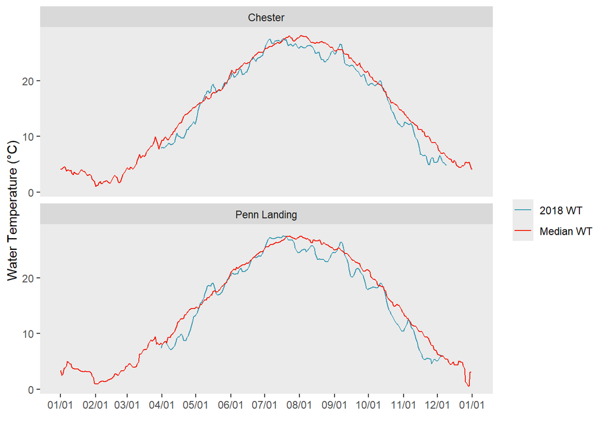

```r
tmp <- rbind(
  df.med %>% select(doy.as.date,wt.med,site) %>%
    mutate(id="Median WT") %>% rename(wt=wt.med),
  df.2018 %>% select(doy.as.date,wt.mean,site) %>%
    mutate(id="2018 WT") %>% rename(wt=wt.mean)
)

# Water Temperature in late summer and fall 2018 was below the median
ggplot(tmp,aes(x=doy.as.date,y=wt,color=id))+
  geom_line()+
  facet_wrap(~site,ncol=1)+
  scale_color_manual(values=pal[c(1,5)])+
  scale_x_date(date_labels="%m/%d",date_breaks = "1 month")+
  no_grid+
  labs(x="",y="Water Temperature (°C)",color="")
```

```r
rm(tmp)
```

## Simulate Fish Size with 2018 Water Temperature (DO=100)

```r
my_Labels <- c(
  as.Date(seq(192,352,by=20),origin="1969-12-31") %>% format(format="%m/%d"),
  as.Date(seq(8,68,by=20),origin="1969-12-31") %>% format(format="%m/%d")
)
my_Breaks <- seq(0,262,by=20)

wt <- df.2018 %>%
  filter(site=="Chester") %>%
  mutate(days=ifelse(doy>=182,doy-181,doy+184),
         bin=cut(days,breaks=my_Breaks,labels=my_Labels)) %>%
  filter(days<163) %>%
  arrange(days)

wt <- wt$wt.mean[1:162]

gr <- rep(NA,163)
gr[1] <- 27
for (i in 1:162) {
  gr[i+1] <- gr[i]*exp(as_growth_model3(TEMP=wt[i],SAL=0,DO=100,GR=gr[i]))
}

# Sample time series every 20 days to match time interval on graph
sim.2018 <- data.frame(bin=factor(my_Labels[1:13]),sim_wt=gr[seq(1,12*20+1,by=20)])
```

## Simulate Fish Size with Median Water Temperature (DO=100)

```r
wt <- df.med %>%
  filter(site=="Chester") %>%
  mutate(days=ifelse(doy>=182,doy-181,doy+184),
         bin=cut(days,breaks=my_Breaks,labels=my_Labels)) %>%
  filter(days<261) %>%
  arrange(days)

wt <- wt$wt.med[1:261]

gr <- rep(NA,262)
gr[1] <- 27
for (i in 1:261) {
  gr[i+1] <- gr[i]*exp(as_growth_model3(TEMP=wt[i],SAL=0,DO=100,GR=gr[i]))
}

# Sample time series every 20 days to match time interval on graph
sim.med <- data.frame(bin=factor(my_Labels[1:13]),sim_wt=gr[seq(1,12*20+1,by=20)])
```

## Plot the Fish Size Data

- use violin plots with time interval of 20 days
- plot the 500 g cut off for Age-0 fish
- plot the observed fish size in each 20 days window (jitter the x-data)
- plot the simulated fish weight (assumes: initial weight of 27 g on 7/1, water temperature is median water temperature, POSAT=100%

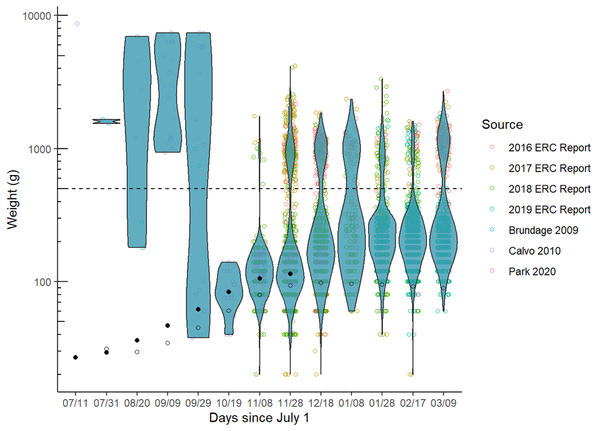

```r
my_Labels <- c(
  as.Date(seq(192,352,by=20),origin="1969-12-31") %>% format(format="%m/%d"),
  as.Date(seq(8,68,by=20),origin="1969-12-31") %>% format(format="%m/%d")
)
my_Breaks <- seq(0,260,by=20)

df <- fish.data %>%
  mutate(days=ifelse(yday(Date)>=182,yday(Date)-181,yday(Date)+184),
         bin=cut(days,breaks=my_Breaks,labels=my_Labels))

ggplot()+
  geom_jitter(data=df,aes(x=bin,y=Weight_g,color=source),shape=1,width=0.2)+
  scale_x_discrete(drop=FALSE)+
  scale_y_log10()+
  geom_violin(data=df,aes(x=bin,y=Weight_g),fill=pal[1],alpha=0.8, scale="width")+
  geom_point(data=sim.2018[1:13,],aes(x=bin,y=sim_wt))+
  geom_point(data=sim.med[1:13,],aes(x=bin,y=sim_wt),shape=1)+
  geom_hline(yintercept=500,linetype=2)+
  annotation_logticks(sides="l")+
  labs(x="Days since July 1",y="Weight (g)",color="Source")+
  theme_classic()
```